# Lake Michigan Surf and Kite Project

Brice Kramer

```r
library(readr)
GLOS_data_export_45161 <- read_csv("GLOS_data_export_45161.csv", skip = 1)
lake <- GLOS_data_export_45161
library(tidyverse)
library(dplyr)
library(purrr)
library(lubridate)
```

change to shorter column names

```r
lake <- lake %>%
   rename(
     date_time = `Date/Time (UTC)`,
     wind_speed = `Wind_Speed (kts)`,
     wind_gust = `Wind_Gust (kts)`,
     wind_direction = `Wind_from_Direction (degrees_true)`,
     water_temp = `Water_Temperature_at_Surface (fahrenheit)`,
     wave_height = `Significant_Wave_Height (ft)`,
     wave_period = `Significant_Wave_Period (s)`,
     wave_direction = `significant_wave_from_direction (degrees_true)`,
     air_temp = `Air_Temperature (fahrenheit)`,
     air_pressure = `Air_Pressure (mb)`,
     therm_1m = `Thermistor_String_at_1m (fahrenheit)`,
     therm_22m = `Thermistor_String_at_22m (fahrenheit)`
   )
```

add month and year to table

```r
lake$date_time <- mdy_hm(lake$date_time)

 lake <- lake %>%
    mutate(as_datetime(date_time))

 lake <- lake %>%
    mutate(month(date_time, label = TRUE))
lake <- lake %>%
    rename(month_date = `month(date_time, label = TRUE)`)

lake <- lake %>%
   mutate(year(date_time))
lake <- lake %>%
  rename(year_date = `year(date_time)`)

    #check that the months and year converted
lake %>%
  select(date_time, month_date, year_date)%>%
  filter(is.na(month_date), is.na(year_date))
```

```
## # A tibble: 0 × 3
## # … with 3 variables: date_time <dttm>, month_date <ord>, year_date <dbl>
```

finding missing and incorrect data

```r
lake %>%
  summarise(meanWind = mean(wind_speed), minWind = min(wind_speed), maxWind = max(wind_speed))
```

```
## # A tibble: 1 × 3
##   meanWind minWind maxWind
##      <dbl>   <dbl>   <dbl>
## 1    -623. -19436.    194.
```

```r
lake %>%
  filter(wind_speed >=0 & wind_speed < 194)%>%
  summarise(meanWind = mean(wind_speed), minWind = min(wind_speed), maxWind = max(wind_speed))
```

```
## # A tibble: 1 × 3
##   meanWind minWind maxWind
##      <dbl>   <dbl>   <dbl>
## 1     8.62       0    29.3
```

```r
lake %>%
  summarise(meanWave = mean(wave_height), minWave = min(wave_height), maxWave = max(wave_height))
```

```
## # A tibble: 1 × 3
##   meanWave minWave maxWave
##      <dbl>   <dbl>   <dbl>
## 1   -6899. -32805.    328.
```

```r
lake %>%
  filter(wave_height >=0 & wave_height < 30)%>%
  summarise(meanWave = mean(wave_height), minWave = min(wave_height), maxWave = max(wave_height))
```

```
## # A tibble: 1 × 3
##   meanWave minWave maxWave
##      <dbl>   <dbl>   <dbl>
## 1     1.39       0    12.5
```

plot relationship between wind speed and wave size

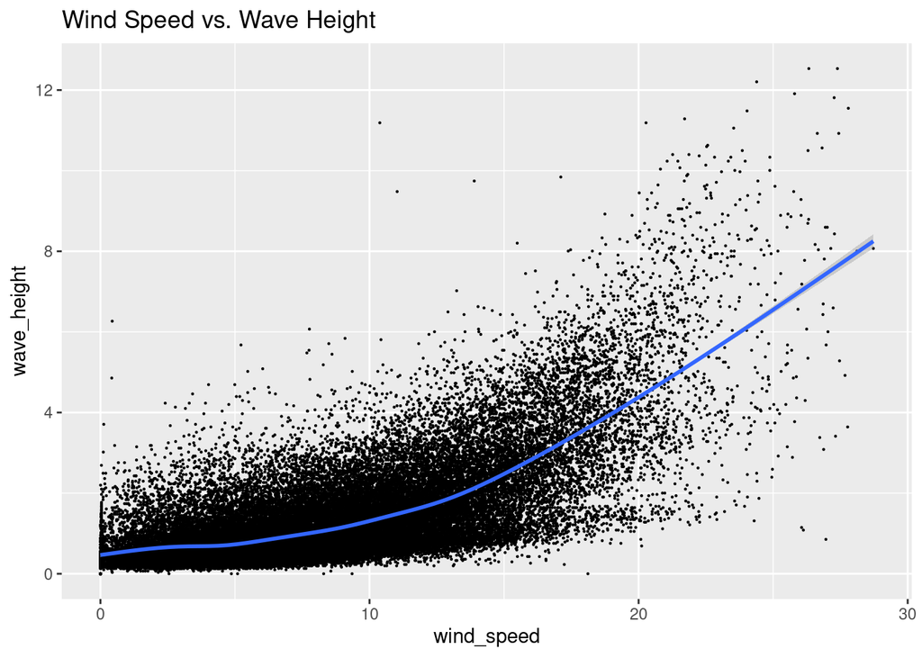

```r
wavewind <- lake %>%
  select(date_time, wind_speed, wave_height, wind_direction, wave_direction, month_date, year_date ) %>%
  filter(wind_speed >= 0 & wind_speed < 150, wave_height >= 0 & wave_height < 30, wind_direction >= 0 & wind_direction <= 360, wave_direction >=0 & wave_direction <= 360) %>%
  arrange(date_time)

ggplot(data = wavewind, mapping = aes(x = wind_speed, y = wave_height))+
  geom_point(size = .1)+
  geom_smooth()+
  labs(title = "Wind Speed vs. Wave Height")
```

plot wave height based on wind direction , 245 is parallel

```r
wavewind %>%
  select(wind_direction)%>%
  summarise(min = min(wind_direction), mean = mean(wind_direction), max = max(wind_direction))
```

```
## # A tibble: 1 × 3
##     min  mean   max
##   <dbl> <dbl> <dbl>
## 1     0  193.   360
```

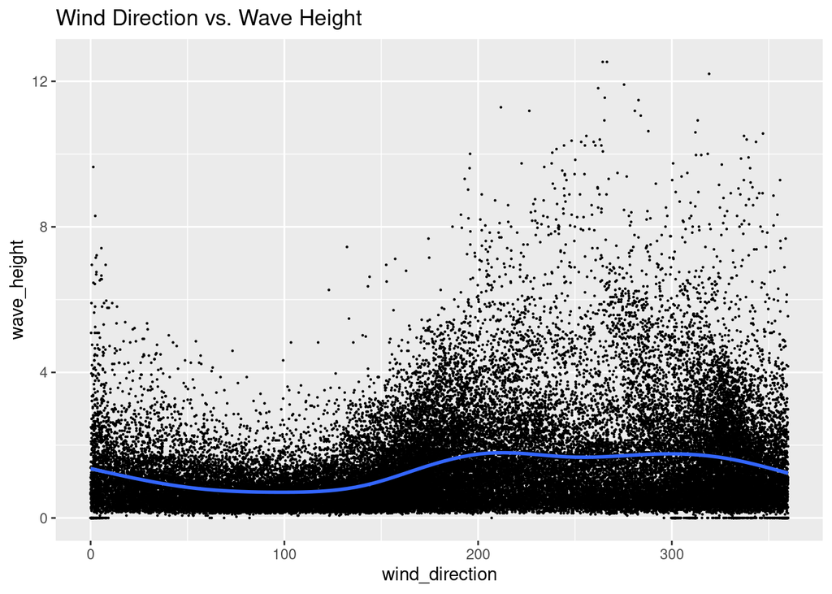

[figure not shown]

[figure not shown]

```r
ggplot(data = wavewind, mapping = aes(x = wind_direction, y = wave_height))+
  geom_point(size = .1)+
  geom_smooth()+
  labs(title = "Wind Direction vs. Wave Height")
```

graph monthly averages of wave height and wind speed

```r
lake %>%
    select(date_time, month_date, year_date, wave_height, wind_speed)%>%
    filter(wave_height >=0 & wave_height < 30, wind_speed >= 0 & wind_speed < 100)%>%
    group_by(month_date)%>%
    summarise(waveH = mean(wave_height), windS = mean(wind_speed))
```

```
## # A tibble: 10 × 3
##    month_date waveH windS
##    <ord>      <dbl> <dbl>
##  1 Mar         0     0
##  2 Apr         1.31  9.37
##  3 May         1.05  8.12
##  4 Jun         1.08  7.86
##  5 Jul         1.12  7.50
##  6 Aug         1.16  7.61
##  7 Sep         1.64  9.55
##  8 Oct         2.45 11.7
##  9 Nov         3.66 14.0
## 10 Dec         1.43  6.70
```

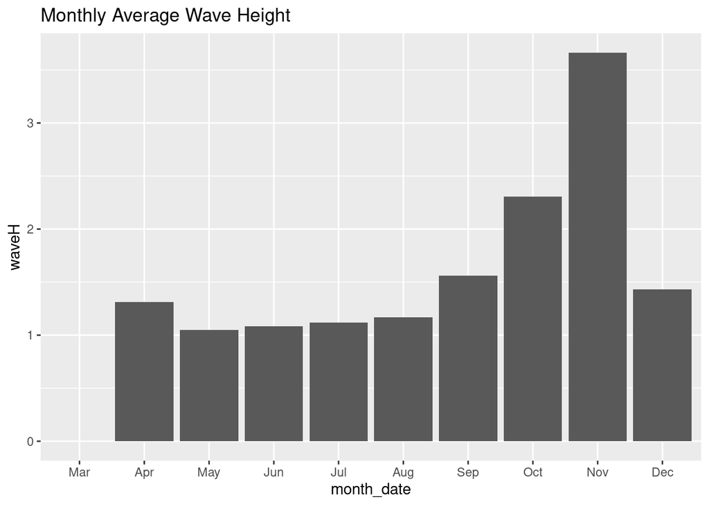

```r
    # Doing the same thing with already filtered subset, Wave
wavewind %>%
  select(date_time, month_date, year_date, wave_height, wind_speed)%>%
  group_by(month_date)%>%
  summarise(waveH = mean(wave_height), windS = mean(wind_speed))%>%
  ggplot(mapping = aes(x = month_date, y = waveH))+
    geom_bar(stat = 'identity')+
    labs(title = "Monthly Average Wave Height")
```

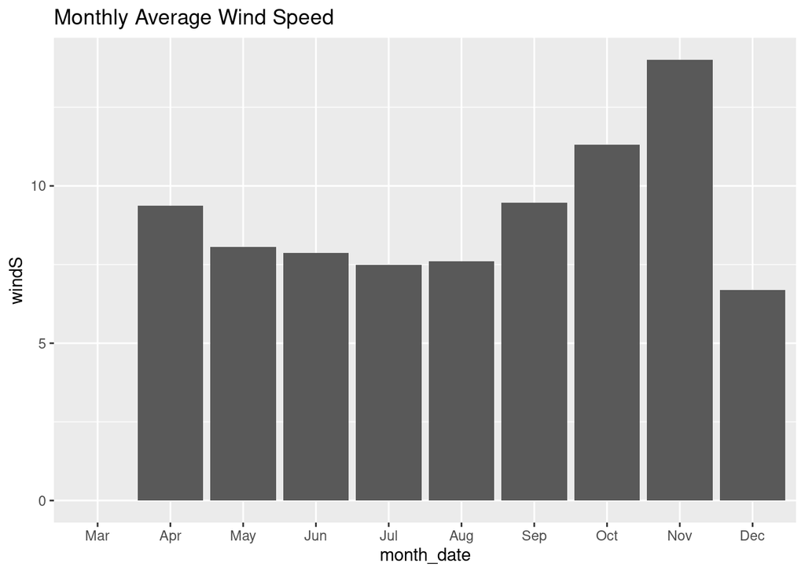

```r
    # Wind
wavewind %>%
  select(date_time, month_date, year_date, wave_height, wind_speed)%>%
  group_by(month_date)%>%
  summarise(waveH = mean(wave_height), windS = mean(wind_speed))%>%
  ggplot(mapping = aes(x = month_date, y = windS))+
    geom_bar(stat = 'identity')+
    labs(title = "Monthly Average Wind Speed")
```

Graph by month and year, missing data makes it less pretty.

```r
byMonthYear <- lake %>%
  select(date_time, month_date, year_date, wave_height, wind_speed)%>%
  filter(wave_height >=0 & wave_height < 30, wind_speed >= 0 & wind_speed < 100)%>%
  group_by(month_date, year_date)%>%
  summarise(waveH = mean(wave_height), windS = mean(wind_speed))
```

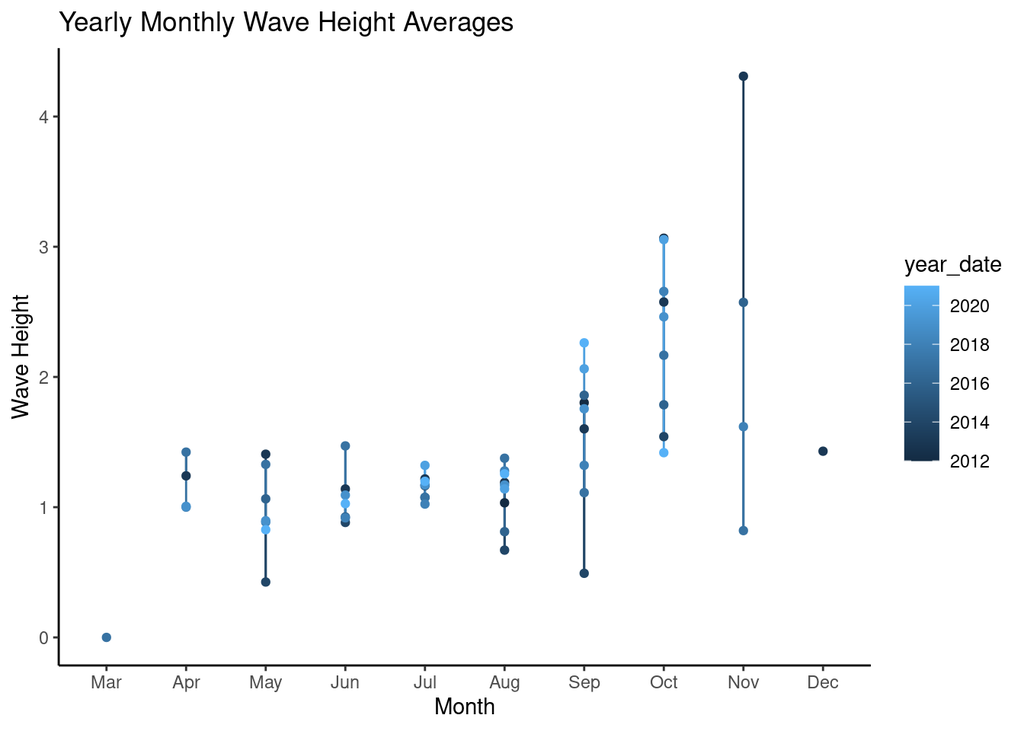

```r
byMonthYear %>%
  ggplot(mapping = aes(x = month_date,label=TRUE, abbr=TRUE, y = waveH, colour = year_date),
         group=factor(year_date))+
  geom_line() +
  geom_point() +
  labs(title = "Yearly Monthly Wave Height Averages", x="Month", y = "Wave Height")+
  theme_classic()
```

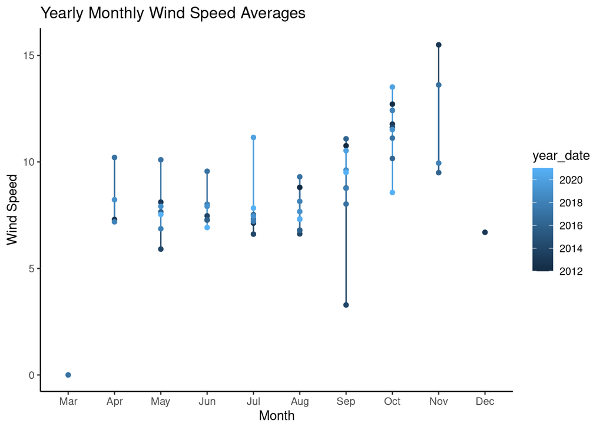

```r
  #by wind
byMonthYear %>%
  ggplot(mapping = aes(x = month_date,label=TRUE, abbr=TRUE, y = windS, colour = year_date),
         group=factor(year_date))+
  geom_line() +
  geom_point() +
  labs(title = "Yearly Monthly Wind Speed Averages", x="Month", y = "Wind Speed")+
  theme_classic()
```

Here is a crazy graph of what I was really trying to do. I couldn’t figure out how to get the averages of each year.

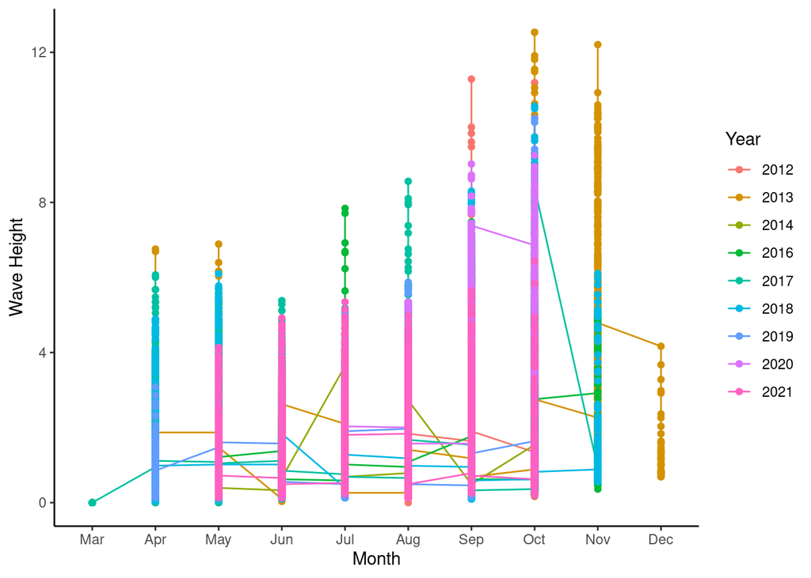

```r
lake %>%
  select(date_time, month_date, year_date, wave_height, wind_speed)%>%
  filter(wave_height >=0 & wave_height < 30, wind_speed >= 0 & wind_speed < 100)%>%
  group_by(month_date, year_date)%>%
  ggplot(mapping = aes(month(date_time, label=TRUE, abbr=TRUE),
     group=factor(year(date_time)), y = wave_height, colour=factor(year(date_time)))) +
  geom_line() +
  geom_point() +
  labs(x="Month", y = "Wave Height", colour="Year") +
  theme_classic()
```

#Focusing on wind data for kiting

```r
wind <- tibble(lake[,c(1:4,14,15)]) %>%
  filter(wind_speed >= 0 & wind_speed < 194)
wind_clean <- wind %>%
  filter(wind_gust != -19436.45616, wind_direction >= 0 & wind_direction <= 360)

wind_clean %>%
  summarise(min = min(wind_gust), mean = mean(wind_gust), max = max(wind_gust))
```

```
## # A tibble: 1 × 3
##     min  mean   max
##   <dbl> <dbl> <dbl>
## 1     0  10.1  41.3
```

```r
  #add mph to wind
wind <- wind %>%
  mutate(mph = wind_speed*1.15078)
```

#focusing on wave data

```r
wave <- tibble(lake[,c(1,6:8, 14:15)])
#removing missing wave height and wave period
wave <- subset(wave, wave$wave_height!= -32805.11916 )
wave2 <- subset(wave, wave$wave_period != -9999 & wave$wave_direction != 0)

wave2 <- wave2 %>%
  filter(wave_direction >= 0 & wave_direction <= 360)

wave2 %>%
  summarize(mean(wave_period), min(wave_period), max(wave_period))
```

```
## # A tibble: 1 × 3
##   `mean(wave_period)` `min(wave_period)` `max(wave_period)`
##                 <dbl>              <dbl>              <dbl>
## 1                2.79               1.61                  6
```

```r
wave2 %>%
  summarize(mean(wave_direction), min(wave_direction), max(wave_direction))
```

```
## # A tibble: 1 × 3
##   `mean(wave_direction)` `min(wave_direction)` `max(wave_direction)`
##                    <dbl>                 <dbl>                 <dbl>
## 1                   218.                  0.03                  328.
```

#surfable waves

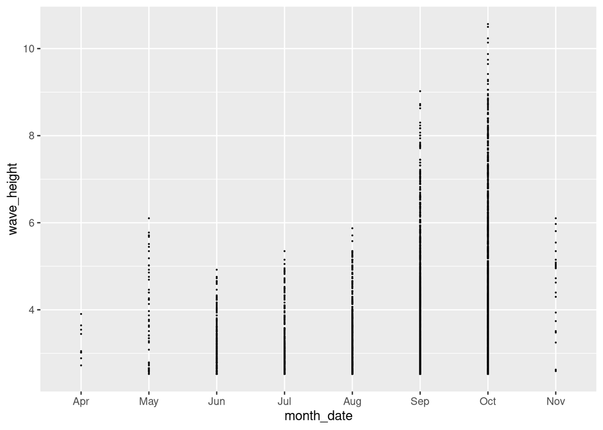

```r
surfWave <- subset(wave2, wave2$wave_height >= 2.5)
surfWave %>%
  ggplot(mapping = aes(x = month_date, y = wave_height))+
  geom_point(size = .1)+
  geom_smooth()
```

```r
surfWave %>%
  count(month_date)
```

```
## # A tibble: 8 × 2
##   month_date     n
##   <ord>      <int>
## 1 Apr            9
## 2 May           55
## 3 Jun          259
## 4 Jul          279
## 5 Aug          570
## 6 Sep         1124
## 7 Oct         1217
## 8 Nov           22
```

```r
wave2 %>%
  count(month_date)
```

```
## # A tibble: 8 × 2
##   month_date     n
##   <ord>      <int>
## 1 Apr          320
## 2 May         3515
## 3 Jun         4074
## 4 Jul         3844
## 5 Aug         6238
## 6 Sep         4374
## 7 Oct         2706
## 8 Nov          130
```

```r
wave %>%
  count(month_date)
```

```
## # A tibble: 10 × 2
##    month_date     n
##    <ord>      <int>
##  1 Mar          338
##  2 Apr         1770
##  3 May         8678
##  4 Jun         9403
##  5 Jul         8207
##  6 Aug        10878
##  7 Sep         8754
##  8 Oct         6470
##  9 Nov          820
## 10 Dec           43
```

Here are “ideal” surfing conditions for somewhere like Maui or California. These condititions are very rare in Michigan. We take any waves.

```r
surfIdeal <- wavewind %>%
  filter(wind_speed > 0 & wind_speed < 10, wave_height >= 2.5 & wave_height < 300)%>%
  arrange(desc(wave_height))

surfIdeal %>%
  summarize(meanWave = mean(wave_height), minWave = min(wave_height),
            maxWave = max(wave_height), meanWind = mean(wind_speed),
            minWind = min(wind_speed), maxWind = max(wind_speed), count =  count(surfIdeal))
```

```
## # A tibble: 1 × 7
##   meanWave minWave maxWave meanWind minWind maxWind count$n
##      <dbl>   <dbl>   <dbl>    <dbl>   <dbl>   <dbl>   <int>
## 1     3.03    2.53    6.27     7.14  0.0365    10.0     856
```

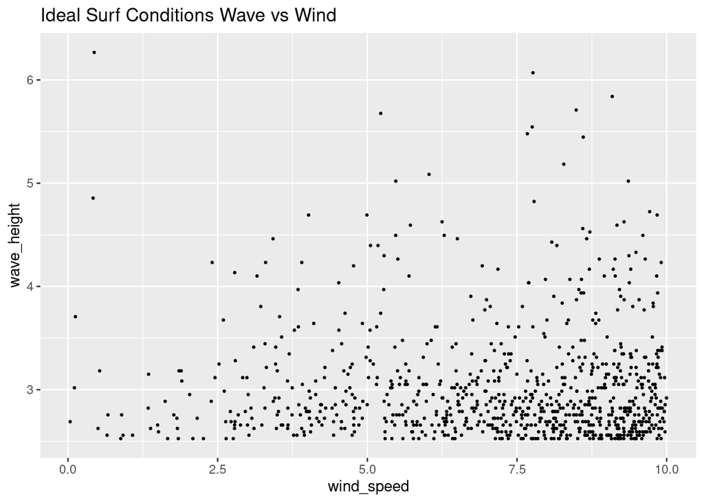

```r
surfIdeal %>%
  ggplot(mapping = aes(x = wind_speed, y = wave_height))+
  geom_point(size = .5)+
  labs(title = "Ideal Surf Conditions Wave vs Wind")
```

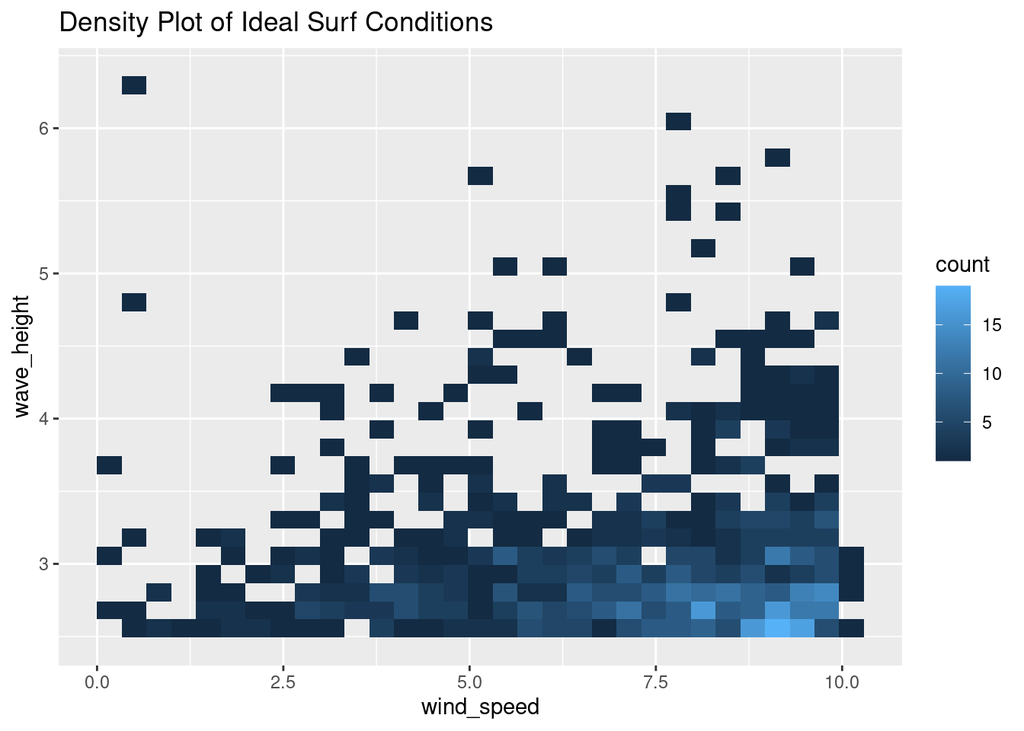

```r
surfIdeal %>%
  ggplot(mapping = aes(x = wind_speed, y = wave_height))+
  geom_bin2d()+
  labs(title = "Density Plot of Ideal Surf Conditions")
```

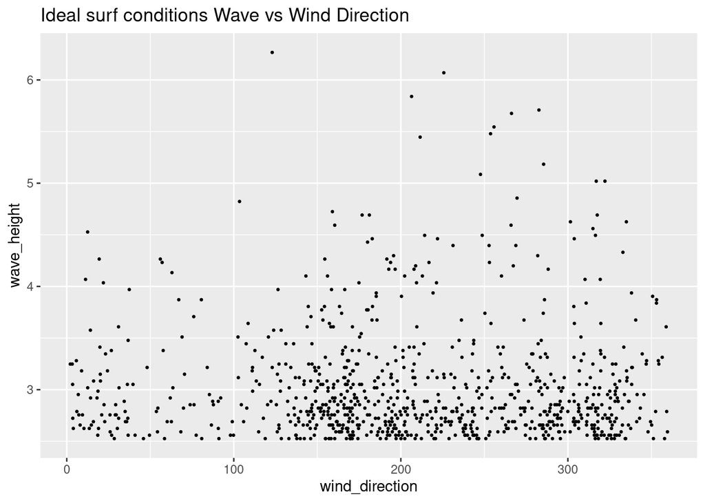

```r
surfIdeal %>%
  ggplot(mapping = aes(x = wind_direction, y = wave_height))+
  geom_point(size = .5)+
  labs(title = "Ideal surf conditions Wave vs Wind Direction")
```

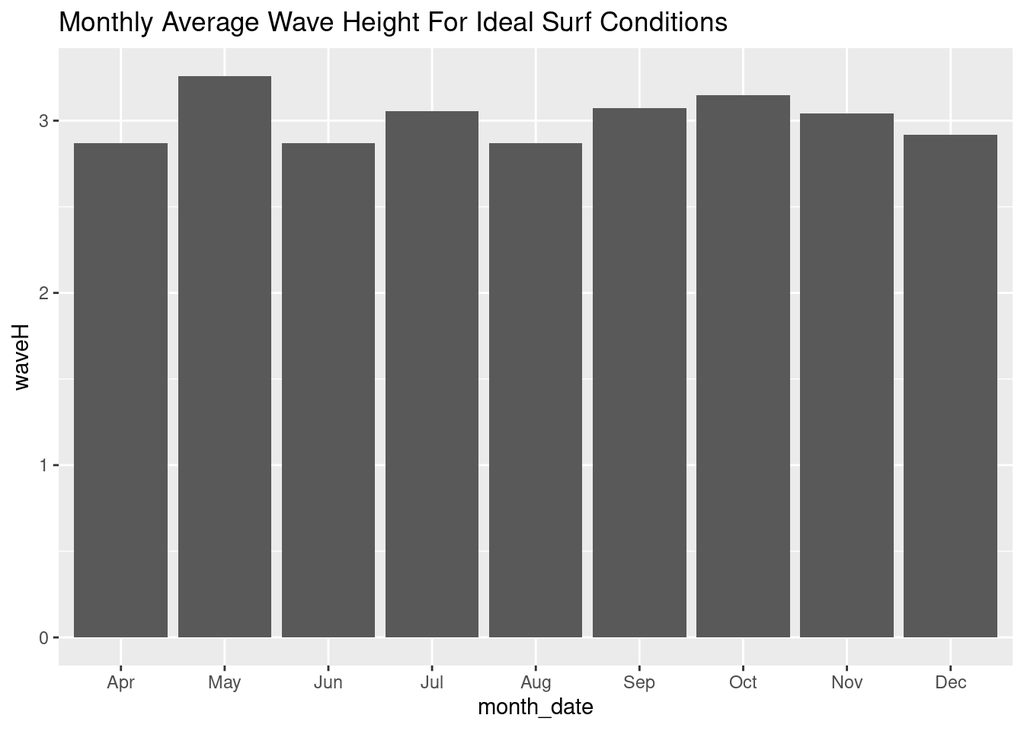

```r
surfIdeal %>%
  select(date_time, month_date, year_date, wave_height, wind_speed)%>%
  group_by(month_date)%>%
  summarise(waveH = mean(wave_height), windS = mean(wind_speed))%>%
  ggplot(mapping = aes(x = month_date, y = waveH))+
  geom_bar(stat = 'identity')+
  labs(title = "Monthly Average Wave Height For Ideal Surf Conditions")
```

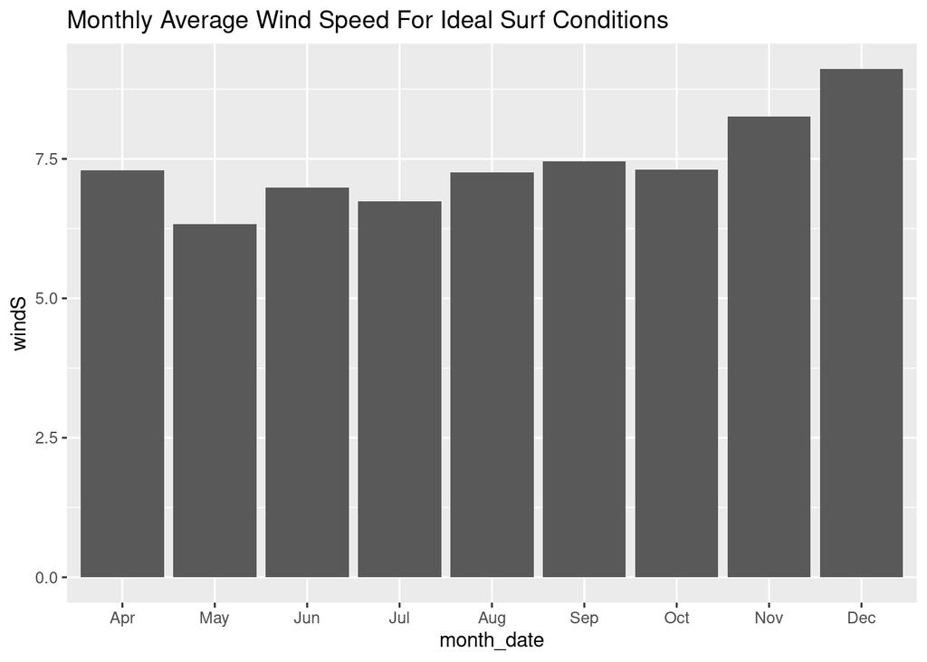

```r
surfIdeal %>%
  select(date_time, month_date, year_date, wave_height, wind_speed)%>%
  group_by(month_date)%>%
  summarise(waveH = mean(wave_height), windS = mean(wind_speed))%>%
  ggplot(mapping = aes(x = month_date, y = windS))+
  geom_bar(stat = 'identity')+
  labs(title = "Monthly Average Wind Speed For Ideal Surf Conditions")
```